# Spatiotemporal dynamics of the ant community in a dry forest differ by vertical strata but not by successional stage - Neves - - Biotropica - Wiley Online Library

[Biotropica](https://onlinelibrary.wiley.com/journal/17447429)

[Early View](https://onlinelibrary.wiley.com/toc/17447429/0/0)

[figure not shown]

REVIEW

Full Access

# Spatiotemporal dynamics of the ant community in a dry forest differ by vertical strata but not by successional stage

[Frederico S. Neves](https://onlinelibrary.wiley.com/action/doSearch?ContribAuthorStored=Neves%2C+Frederico+S)

[Reuber Antoniazzi](https://onlinelibrary.wiley.com/action/doSearch?ContribAuthorStored=Antoniazzi%2C+Reuber)

[Flávio Camarota](https://onlinelibrary.wiley.com/action/doSearch?ContribAuthorStored=Camarota%2C+Fl%C3%A1vio)

[Fábio T. Pacelhe](https://onlinelibrary.wiley.com/action/doSearch?ContribAuthorStored=Pacelhe%2C+F%C3%A1bio+T)

[Scott Powell](https://onlinelibrary.wiley.com/action/doSearch?ContribAuthorStored=Powell%2C+Scott)

First published: 08 February 2021

https://doi.org/10.1111/btp.12918

Associate Editor: Jennifer Powers

Handling Editor: Terrence McGlynn

## Abstract

Ants are diverse and ecologically important organisms in tropical forests, where their spatiotemporal distribution can be highly complex. This complexity arises mainly from marked differences in microclimatic conditions and resource availability through space and time that is even more evident in highly seasonal environments, such as tropical dry forests. However, it is unclear how seasonality interacts with other factors that might shape temporal variation of ant composition (β‐diversity), like vertical strata and habitat disturbance. Our goal was to examine the potential influence of vertical stratification and the successional stage on the spatiotemporal variation of a tropical dry forest's ant species composition. We assessed whether species turnover or nestedness was the main component determining the spatiotemporal β‐diversity of ant communities across the canopy and litter strata. We sampled canopy and litter ants in ten plots, half in the early and half on the late stage of secondary succession at four times, twice in wet and twice in dry season. A high species turnover defined the spatiotemporal β‐diversity of canopy and litter ant communities across years and seasons in our focal dry forests. Importantly, the temporal ant species composition was much more stable in the canopy than in the litter. Moreover, we found that the ant community's temporal dynamics was consistently high across successional stages, not differing in the temporal β‐diversity between early and late succession. Our results provide valuable insights into the potential underlying causes of community assembly and spatiotemporal dynamics in seasonal habitats, like the highly threatened and diverse tropical dry forests.

Abstract in Portuguese is available with online material.

## 1 INTRODUCTION

Insects dominate tropical forests in both diversity and abundance (Basset et al., 2012, 2015), and their spatial and temporal distribution can be highly complex and variable in such ecosystems (Basset et al., 2015). This complexity arises mainly through differences in microclimatic conditions and variations in resource availability through space and time (Bigger, 1976; Wardhaugh, 2014; Wolda, 1988). These variations become even more evident when the insect diversity is analyzed among different strata and seasons of highly seasonal environments, such as tropical dry forests (Beirão et al., 2017; Kishimoto‐Yamada & Itioka, 2015; Neves et al., 2014; Novais et al., 2019). Nevertheless, how seasonal fluctuations interact with other influences on spatial and temporal variation of insect's composition in tropical dry forests, like vertical strata and habitat disturbance, remains mostly unexplored. There is a substantial change in habitat conditions between soil and canopy strata (Shaw, 2004), and this vertical stratification is often considered a key factor promoting the diversity of animals in tropical forests (e.g., Bernard, 2001; Molleman et al., 2006; Oliveira & Scheffers, 2019). This is mainly because the vertical stratification is associated with major shifts in biotic communities, highlighting the great variety of niches and high species coexistence possible at small scales in tropical forests (Brown, 1981; Mottl et al., 2020; Scheffers et al., 2017). Understanding how species distributions respond to habitat changes from the soil to the upper canopy and how seasonality affects these changes is thus an important goal of tropical biology (Basset et al., 2003; Grimbacher & Stork, 2007; Roisin et al., 2006; Tobin, 1997).

Tropical dry forests are characterized by a prolonged dry season that restricts the productivity of plants to the 3–5 months per year when rainfall is highly concentrated (Sanchez‐Azofeifa et al., 2005). These annual cycles of short periods of precipitation and long periods of drought are synchronized with changes in the biota of these ecosystems (e.g., phenology: Pezzini et al., 2014). The seasonal shifts that occur in the plant organs and structures in tropical dry forests promote changes in distinct groups of animals and integrate an important temporal process (Beirão et al., 2017; Neves et al., 2013; Novais et al., 2019). Changes in plant phenology may have distinct effects on the fauna inhabiting different habitats of the forest. For example, the canopy fauna, and especially the small ectotherms, is presumably adapted to constant solar radiation (Kaspari et al., 2015), and this does not change drastically across seasons in tropical environments (Lindzen, 1994). However, studies on climatic conditions in forests have shown an increase in solar irradiance in the ground layer due to canopy gaps (Brown, 1993), and temperature extremes become higher as open areas of the canopy increase in size (Barton et al., 1989; Carlson & Groot, 1997). The forest understory, the vertical stratum below the canopy, then faces drastic changes in its microclimatic conditions during the dry season, when the partially defoliated canopy intercepts less solar radiation (Barton et al., 1989; Brown, 1993). This shift in microclimatic conditions might be particularly strong in dry forests, where the changes in canopy structure are even more drastic, with about 90% of the trees with no leaves or considerably fewer leaves in the dry season (Pezzini et al., 2014; Silva et al., 2015). Studies in tropical forests have revealed that a large part of the insect fauna living in the forest understory and ground strata is highly sensitive to solar radiation (Bujan et al., 2016; Kaspari et al., 2015). However, the knowledge of how the increase in exposure to direct sunlight may influence the compositional reorganization of insect communities is still scarce.

In addition to temporal variation of insect communities being driven by seasonality, resource utilization by insects can also vary substantially across forest strata. This variation is related to the differences in the quality of these resources, as well as their predictability and temporal stability. Among the organisms found in the different forest strata, ants are exceptional in both diversity and biomass (Hölldobler & Wilson, 1990; Lach et al., 2010; Tobin, 1997). Ants have varied diets, including seeds, plant and trophobiont exudates, other insects, and even other ants (Hölldobler & Wilson, 1990; Lach et al., 2010). Although the availability of food resources often changes over time (Lanan, 2014), this availability is not markedly different between forest strata. Contrastingly, the availability of shelter resources can shift drastically between forest strata on the temporal scale. The majority of arboreal ant species nest in hollow cavities of different sizes, in live and dead wood, which can be highly persistent through time (Klimes, 2017; Novais et al., 2018; Powell, 2016). On the other hand, many tropical litter‐dwelling ants nest in more ephemeral, decaying materials such as fallen branches and other plant debris (Byrne, 1994; Fernandes et al., 2012; Kaspari, 1996; Macedo‐Reis et al., 2019; Novais et al., 2020; Sagata et al., 2010). The canopy is therefore likely to have more persistent shelter resources and a less drastic shift in microclimatic conditions across seasons than the litter. The differences in resource persistence and environmental conditions, even if minor, should promote distinct influences on the dynamics of ant communities inhabiting both vertical strata. While the temporal variation of ant community composition in tropical forests has been addressed in a number of prior studies (e.g., Basset et al., 2015; Delsinne et al., 2013; Donoso, 2017), only a few studies assessed this variation between different forest strata (Jacquemin et al., 2016; Marques et al., 2017).

Ants are sensitive to habitat transformation by humans, because modified habitat structures support different ant communities (Andersen, 2019; Solar et al., 2016). Among tropical forests, dry forests are highly threatened ecosystems, with a constant increase in forest gaps due to anthropogenic activities in the last decades, and the majority of such habitats consist of a mosaic of forests in different stages of vegetation succession (Quesada et al., 2009). Importantly, forest succession drives changes in the insect community structure in different ecosystems (Boege et al., 2019; Bongers et al., 2004; Jeffries et al., 2006). In particular, variation in ant communities across forest succession has been associated with changes in forest complexity and heterogeneity of micro‐environmental conditions (Klimes et al., 2012; Marques et al., 2017) but can result in unpredictable patterns in the canopy (Antoniazzi et al., 2019). Shifts in microclimatic conditions and distribution of potential resources may also be altered by forest gaps (d’Oliveira & Ribas, 2011) and anthropogenic activities that leave regions of a forest in distinct stages of secondary succession (Fibich et al., 2016). These changes can act similarly to the vertical stratification, with marked differences in sunlight radiation and resource availability.

Assessing spatiotemporal changes in species composition (β‐diversity) can be helpful in understanding both spatial and temporal scales of compositional stability (Anderson et al., 2011; Baselga, 2010; Basset et al., 2015). This approach therefore has considerable potential for addressing the influence of both the successional stage and strata on ant communities. Ecological stability, the inverse of variation over time, is a fundamental ecosystem property that offers insights into biodiversity and ecosystem processes (Doak et al., 1998; Joseph et al., 2019; Tonkin et al., 2017). Critically, β‐diversity can be decomposed into the turnover and nestedness components, which provide complementarity insights into community ecological stability: the turnover component reflects species replacement, while the nestedness component reflects species richness differences driven by a pattern of community subsetting (Baselga, 2010). Recently, species turnover has been consistently shown to be the main component of total β‐diversity across a wide range of taxa and ecosystems (Antão et al., 2019; Soininen et al., 2018), and a recurrent feature among insect communities in dry forest areas (Leal et al., 2016; Macedo‐Reis et al., 2019; Silva et al., 2017). However, the turnover of ant communities in the temporal scale is still largely unexplored. Additionally, little is known about the potential influences of factors such as vertical stratification and forest succession on the degree of turnover in these communities.

In this study, we examine the influence of forest strata and the successional stage on the spatiotemporal variation of ant communities in a tropical dry forest. In particular, we test whether turnover or nestedness is the main component that determines the temporal changes in species composition (β‐diversity) of the canopy and litter ant communities. In tackling our main goal, we address the following specific hypotheses: (a) The composition of the ant community in the canopy is more stable temporally (lower β‐diversity) than the litter community, and (b) the ant community composition associated with the early successional stage is more temporally dynamic (greater β‐diversity) than the ant community in the late successional stage. The first hypothesis follows from the understanding that the temporal shifts in microclimatic conditions, such as solar radiation, are more extreme for the ants at the ground level, relative to the seasonal effects on the trees. Additionally, the nesting resources are more ephemeral in the litter (McGlynn, 2012) than in the canopy. These two factors can potentially drive a signature of greater instability in the ant community in the litter in comparison with canopy stratum. Likewise, our second hypothesis follows from the possibility that microclimatic conditions and resource availability may be more variable in earlier stages of succession, potentially driving higher temporal beta diversity of the ant composition.

## 2 METHODS

### 2.1 Study area

We conducted this study in *Parque Estadual da Mata Seca* (PEMS; 14°48′36″ – 14°56′12″ S and 43°55′12″ – 44°04′12″ W; 493 m a.s.l.), in SE Brazil. The PEMS is located in a transition zone between three major Brazilian biomes: *Cerrado* (Brazilian savanna), *Caatinga* (spiny‐dry forest), and *Mata Atlântica* (Atlantic Forest). With a total area of 15,466 ha, the PEMS is inserted in a mosaic of primary and secondary (previously used for agriculture and livestock activities) forests (Madeira et al., 2009). The climate of the region is tropical semi‐arid (Alvares et al., 2013), characterized by a severe dry season from May through September and a wet season from November through April. The average annual precipitation is 818 ± 242 mm (mean ± *SD*), which is concentrated in the wet season months, and the average annual temperature is 25.1°C (Pezzini et al., 2014).

The whole study area was covered originally with tropical dry forests on fertile soils and mostly level terrain. The tropical dry forest of the area is comprised of deciduous vegetation that loses more than 90% of its leaves in the dry season (Pezzini et al., 2014). We chose areas belonging to two successional stages, hereafter early and late stages, with remarkable differences in their structure and land‐use history (Madeira et al., 2009). The early‐stage area was a pasture and has been in recovery for about 15 years. The early‐stage contains mixed vegetation of trees less than 8 m in height, herbs, and grasses, without distinct vertical stratification. The late‐stage area has had little to no anthropogenic disturbance for at least the last 60 years, with emerging trees that exceed 20 m in height. Moreover, the late‐stage area has distinct canopy and understory strata, with direct sunlight reaching the soil level only in the dry season when the trees have lost their leaves. The late‐stage areas also have low densities of new trees and lianas compared to other adjacent areas at different stages of regeneration (for a detailed description of the study areas, see Madeira et al., 2009).

### 2.2 Ant sampling

We sampled ants in the canopy and litter strata in ten 20 m × 50 m rectangular plots . These plots were spaced at least 200 m apart along a 7‐km transect, with five in the early stage and five in the late stage of secondary succession (Figure 1). Plots from the same successional stage were located 0.2–1.0 km from each other (Antoniazzi et al., 2019; Madeira et al., 2009). All ten plots were subjected to similar topographic and climatic conditions, regardless of their successional stage (see Madeira et al., 2009). We acknowledge that the spatial distribution of our plots represents a pseudoreplicated design (i.e., “clumped segregation”; sensu Hurlbert, 1984), but it is not considered a serious concern when monitoring natural experiments where site and disturbance/treatment effects may be confounded (see Davies & Gray, 2015; Oksanen, 2001). In each plot, we chose a grouping of three trees at each of the four corners and in the center of each plot to sample ants, giving a total of 15 trees and litter samples per plot. The plots were sampled four times, twice in the dry season (September 2010 and September 2011) and twice in the wet season (February 2011 and February 2012). The ant richness in each stratum over the four periods was then used to calculate the beta‐temporal diversity, as described below.

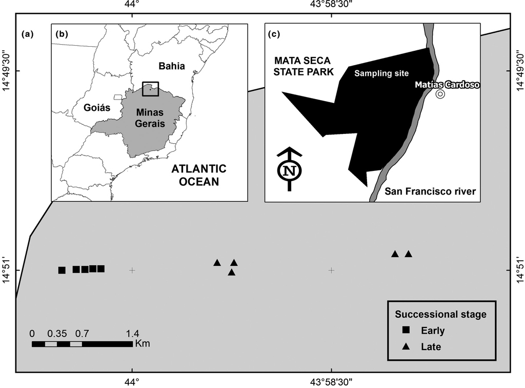

**FIGURE 1**

Open in figure viewer[PowerPoint](https://onlinelibrary.wiley.com/action/downloadFigures?id=btp12918-fig-0001&doi=10.1111%2Fbtp.12918)

Maps showing the position of *Mata Seca* State Park in *Minas Gerais* state, Brazil, and the extent of the study area. Each square and triangle represent a single plot of early and late successional stages, respectively. The *São Francisco* river is provided for reference

We used specific methods for sampling the ants in each stratum. In the canopy, we used two complementary techniques: arboreal pitfall trapping and an entomological beating technique (Antoniazzi et al., 2019; Campos et al., 2006). Arboreal pitfall trapping consisted of placing 15 cm diameter plastic pots filled with water and soap and collecting after 48 h. The entomological beating technique consisted of using an entomological umbrella made from an inverted cloth funnel, with a surface of 1 × 1 m, and a plastic bag attached to the bottom (for more details, see Antoniazzi et al., 2019). To sample the ground‐dwelling ants, we used the Mini‐Winkler method, a widely used technique to collect arthropods that live in the litter (Belshaw & Bolton, 1993; Castro et al., 2012; Silva & Brandão, 2010). At each sampling point below a tree, the litter from 1m<sup>2</sup> was collected and sieved through 1‐cm<sup>2</sup> mesh. The filtered material was then placed in the Mini‐Winkler extractor that was suspended for 48 hr (see Fisher, 1999) so that the associated fauna fell into the collecting pot.

We transported all the sampled material to the laboratory for sorting, and the ants were mounted and identified to the lowest possible taxonomic level. First, we identified all ants to genera using Baccaro et al. (2015). For species identification, we then used a combination of the keys of “Ants of Costa Rica” (Longino, 2007), and the information and images available on “AntWeb” (Fisher, 2002). For the current valid taxonomic name of each species, we consulted “AntCat” (Bolton, 2012). Our species determinations were then further verified by a reference collection from previous work in the same area (Antoniazzi et al., 2019). We deposited all material in the *Laboratório de Ecologia de Insetos* (LEI), *Universidade Federal de Minas Gerais* (UFMG), Brazil.

### 2.3 Statistical analysis

Firstly, we assessed the sampling completeness of the ant species for each successional stage separately. For this, we used the rarefaction and extrapolation (the number of samples doubled) of ant species richness (Chao et al., 2014), since the ant fauna was recorded using Winkler in the litter and arboreal pitfalls and beating at the canopy. The sample units (i.e., ten plots per time period and four time periods, totaling 40 samples) were used as the independent variable and ant species richness was the dependent variable. Thus, we were able to obtain information about the completeness of ant species in relation to each sampling unit added. We also assessed the alpha diversity in our smallest sampling unit for each successional stage apart, that is, early and late. For this, we used the hill number <sup>0</sup>D to show the observed species richness accumulated for our sampling units, with their confidence intervals. The overlapping of confidence intervals indicates that the two treatments present the same species richness. For the sampling coverage and the species richness, we used the package iNEXT (Hsieh et al., 2016) for R software (R Development Team, 2019).

We assessed the spatial and temporal variation of the ant species composition (β‐diversity) using the Sørensen dissimilarity in a multiple‐space and time approach (see Baselga, 2010). For spatial analyses, the multiple samples from each stratum, that is, litter and canopy, were pooled per plot for subsequent analyses. For temporal analyses, the multiple samples from a stratum within a plot were pooled for each time period, to give four plot‐level data points for each stratum and each plot for subsequent analyses. We then calculated the spatial and temporal β‐diversities (β<sub>SOR</sub>) using the presence/absence of species for each stratum and plot (10 plots in total) for spatial analyses, and over the four sampling periods for each stratum and plot (10 plots in total) for temporal analyses. The β‐diversities (spatial and temporal) were further partitioned into the components derived from species turnover (β<sub>SIM</sub>) and the derived component of nestedness, that is, species gain/loss (β<sub>NES</sub>), using the β‐diversity partitioning method components. We used the "*beta.multi*" function of the R package betapart to the partition of spatial and temporal β‐diversities (Baselga & Orme, 2012).

Finally, we used the temporal β‐diversity (β<sub>SOR</sub>) to test the predictions that the temporal β‐diversity is higher in the litter and early stage than in the canopy and late stage. To compare the temporal β‐diversity values we used a generalized linear mixed model (GLMM) with stratum, successional stage and the interaction between these variables as the fixed effect variables, and the identity of each successional plot as a random factor to account for spatial pseudoreplication (Bolker et al., 2009). We used the Gaussian error distribution, and we checked for the error distribution and over‐dispersion of the data (Crawley, 2013). We defined the minimal model after the removal of non‐significant variables (*p‐value* > .05). We performed all analyses using the R software environment for statistical computing (R Development Team, 2019).

## 3 RESULTS

### 3.1 Ant Sampling

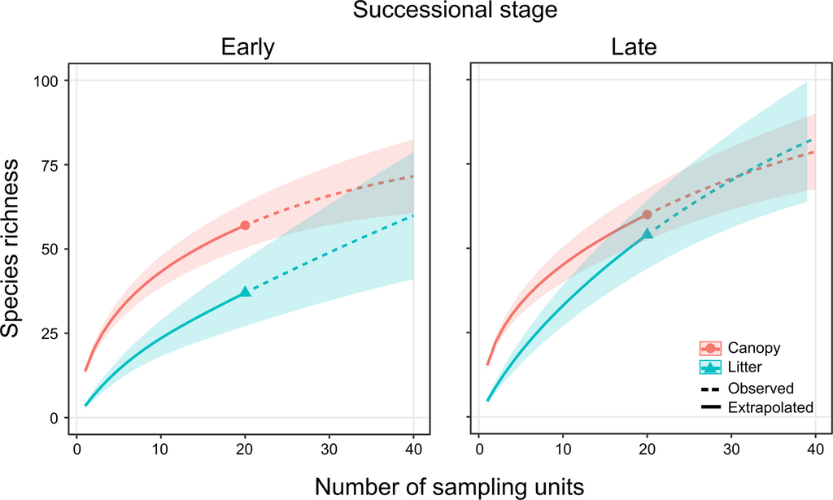

**FIGURE 2**

Open in figure viewer[PowerPoint](https://onlinelibrary.wiley.com/action/downloadFigures?id=btp12918-fig-0002&doi=10.1111%2Fbtp.12918)

Species richness curves (<sup>0</sup>D) for samples (solid lines) and extrapolated samples (dashed lines) as a function of sample size according to the count of incidences of ant species in each sampling unit. The bar error represents the 95% confidence interval. The red circles in the red line represent the observed samples for canopy and the blue triangle for the litter, obtained by a bootstrap method based on 1,000 iterations

### 3.2 β‐Diversity Patterns

Spatial and temporal β‐diversity was mainly driven by species turnover (β<sub>SIM</sub>) in both strata (Table 1), leaving limited importance of nestedness (β<sub>NES</sub>), such that turnover accounted for over 90% spatial dissimilarity and over 85% of the temporal dissimilarity (Figure 3). The high turnover means that in both canopy and litter, the differences in community species composition through space and time are mostly explained by a pattern of species replacement instead of a pattern of community subsetting. Indeed, there was little overlap in species composition between vertical strata. Moreover, we also found that different ant genera were more prevalent in each stratum and successional stage. Species of the genera *Crematogaster*, *Cephalotes*, and *Pseudomyrmex* were collected almost exclusively in the canopy in our study. Within the canopy stratum, ants of the genus *Azteca* were only collected in the late stage. Similarly, species of the genus *Nylanderia* (two species) were only collected in the litter stratum in the late stage.

TABLE 1. Total β‐diversity (βsor; spatial and temporal), separated in the components, turnover (βsim), and nestedness (βnes) for canopy and litter

| β‐diversity | Canopy | Litter |
| --- | --- | --- |
| Spatial |  |  |
| Turnover (βsim) | 0.72 | 0.81 |
| Nestedness (βnes) | 0.03 | 0.06 |
| Beta total (βsor) | 0.74 | 0.87 |
| Temporal |  |  |
| Turnover (βsim) | 0.46 | 0.82 |
| Nestedness (βnes) | 0.08 | 0.10 |
| Beta total (βsor) | 0.54 | 0.92 |

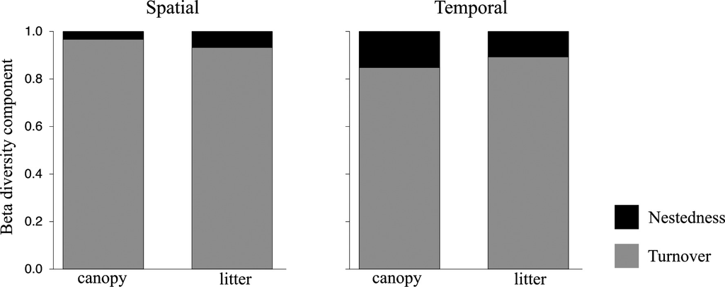

**FIGURE 3**

Open in figure viewer[PowerPoint](https://onlinelibrary.wiley.com/action/downloadFigures?id=btp12918-fig-0003&doi=10.1111%2Fbtp.12918)

Using the GLMM, we found support for our hypothesis that the composition of the ant community in the canopy is more stable temporally (lower β‐diversity) than the litter community (Table 2, Figure 4). Consequently, this supports the biological interpretation that community composition is more variable for litter nesting ant species. β‐diversity was also generally high across successional stages (Figure 4). Nevertheless, we did not observe significant differences in β‐diversity across successional stages (Figure 4), indicating that compositional variability in the ant communities remains high as succession progresses in the focal system. The interaction between stratum and the successional stage was also not a significant predictor of β‐diversity (Table 2).

TABLE 2. Results of generalized linear mixed model (GLMM) with the temporal variation of the ant species composition (β‐diversity) using the successional stage, stratum, and the interaction between these variables as explanatory variables. We used the Gaussian error distribution

| Response variables | Explanatory variables | *df* | Deviance | *p* |
| --- | --- | --- | --- | --- |
| β‐diversity | Successional stage | 1 | 1.071 | .301 |
|  | Vertical strata | 1 | 53.678 | <.0001 |
|  | Interaction of successional stage: vertical strata | 1 | 0.928 | .335 |

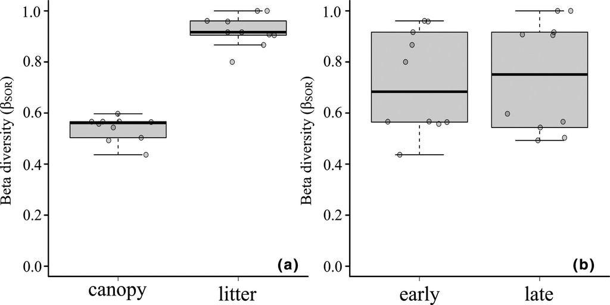

**FIGURE 4**

Open in figure viewer[PowerPoint](https://onlinelibrary.wiley.com/action/downloadFigures?id=btp12918-fig-0004&doi=10.1111%2Fbtp.12918)

Boxplots of temporal variation of the ant species composition (β‐diversity) in the canopy and litter strata (a) and in early and late successional stages (b). In each boxplot, the box encompasses the interquartile range, a line is drawn at the median, and the whiskers extend to the upper and lower quartiles (± 1.5 times the interquartile range). Values are also provided for each sampled plot (circles)

## 4 DISCUSSION

Different effects of seasonality on the microhabitats of the canopy and the litter may be linked to the higher temporal stability of species composition of ants, as we found in this study. In tropical forests, there is a vertical gradient of microclimatic conditions from the ground level to the canopy, with an increase of temperatures and solar radiation, and a decrease in air humidity (Kaspari et al., 2015; Law et al., 2019). Moreover, there are not equally regular changes in microclimatic conditions between the litter and canopy strata across seasons. While the canopy is exposed to sunlight the whole year in tropical forests, the litter environment changes abruptly from the wet to the dry season in tropical dry forests, due to the falling leaves in dry season, resulting in an intense exposure to sunlight on a previously shaded habit. Additionally, the solar radiation reaching the forest floor varies considerably with the structure and architecture of the trees (Allen et al., 1975), and any alteration on canopy structure can dramatically increase the temperature of the litter stratum (Brown, 1993; Carlson & Groot, 1997; Yang et al., 1993). Such abrupt changes might be a key explanation as to why the composition of ants, vulnerable to overheating and desiccation (Bujan et al., 2016), had more drastic changes over time in the litter. Even though plasticity in thermal tolerance is likely, it favors some species of ants over others, a factor that would still foster high community dynamics (Bujan et al., 2020; Spicer et al., 2017). While the canopy environment is not necessarily stable or uniform (Kaspari et al., 2015), the shift in conditions is potentially less extreme than in the litter stratum. Additionally, in the dry season, when there are few or no leaves on the trees, canopy ants that are already more adapted to harsher conditions (Bujan et al., 2016; Kaspari et al., 2015) can simply change their foraging behaviors. Indeed, ant activity in the forest tends to be lower in the dry season (e.g., Kaspari & Weiser, 2000), and this trend is usually stronger for those ant species that are less adapted to extreme conditions, like the majority of litter‐dwelling ants. More specifically, less thermally resistant ants can seek shelter during the hotter times of the day (Bestelmeyer, 2000; Cerdá et al., 1997), or restrict their activities to shaded areas of the remaining structures (e.g., branches; Spicer et al., 2017). In the litter, ants face an extreme increase in solar radiation during the dry season, when most leaves fall from the trees, and while they can shift their period of activity, some species can migrate to less extreme adjacent habitats (Jacquemin et al., 2016). This fact, coupled with the expected lower thermal tolerance of ground‐nesting ants (Kaspari et al., 2015), may help explain why we detected a much more dynamic community in the litter stratum.

The canopy and litter environments are distinct habitats with different climatic conditions, but associated differences in resource quality and availability may also contribute to the differences in temporal stability of species composition that we detected here. While food resources can be more predictable and of higher quality in tropical canopies (Yanoviak & Kaspari, 2000), they can be more variable and changeable in more seasonal biomes (Belchior et al., 2016; Castro et al., 2020). For instance, extrafloral nectary activity can change substantially between wet and dry seasons, yet there is still little evidence of changes in extrafloral nectar availability altering the arboreal ant fauna through time (Antoniazzi et al., 2019; Camarota et al., 2015). Moreover, there are striking differences in the quality and stability of shelter resources between the canopy and litter strata. On the one hand, shelter availability in the litter is limited to ephemeral resources, because although many ground‐nesting species nests in the soil, many others occupy ephemeral structures, as fallen twigs, branches, dry fruits, seeds, and leaves that are in advanced stages of decay (Souza‐Campana et al., 2017; Fernandes et al., 2012). On the other hand, tropical arboreal ants have higher quality shelter resources in the form of cavities in good condition live and dead tree wood and lianas, as well as cavities in epiphytes (Adams et al., 2019; Calderón‐Cortés et al., 2011; Carroll, 1979; Klimes, 2017; Novais et al., 2018; Satoh et al., 2016). Many of these natural cavities are produced by wood‐boring beetles and are usually especially stable, persisting through the lifetime of a tree individual (Blüthgen & Feldhaar, 2010). Moreover, different ant species often prefer different cavity properties, which is dictated by physical constraints and defensibility of the nest entrance in at least one well‐studied genus of arboreal ants (Powell, 2009, 2016; Powell et al., 2020). Previous studies have shown that the nesting ecology of twig nesting ants can be highly dynamic (Byrne, 1994; Kaspari, 1996; McGlynn, 2006, 2012) and have provided evidence of stronger nest‐site limitation in the canopy than in the litter (Mottl et al., 2020). Thus, our finding of higher temporal stability of species composition in the canopy may be linked not just to differences in microclimatic conditions, but also to reliable food availability and the greater persistence of high quality but limited shelter resources in this stratum. Finally, it is necessary to acknowledge that the sampling completeness was higher for canopy ants, possibly inflating the turnover observed in the litter compared to the canopy.

We did not find differences in the temporal dynamics of species composition between successional stages, with high β‐diversity in both the early and late successional stages. This result is somewhat surprising, especially because there is a significant change in the richness and composition of ant species with the advance of the successional secondary vegetation (Marques et al., 2017; Neves et al., 2013). Studies carried out in savannas and mountain ecosystems have found that greater habitat complexity should minimize the variation of ant diversity over time (Joseph et al., 2019; Mauda et al., 2018; Tiede et al., 2017), which is contrary to our finding of high variation even in the late stage. However, it is important to note that tropical dry forests are strongly seasonal, and the ant fauna might have evolved to cope with natural variations under these habitat conditions. Indeed, the life histories of a wide range of organisms can be intimately connected to the seasonality of their habitats (Delsinne et al., 2013; Tonkin et al., 2017), and high levels of seasonality can be positively linked with a high temporal β‐diversity (Tilman & Pacala, 1993; Tonkin et al., 2017). Tropical dry forests have a highly predictable seasonal pattern (Pezzini et al., 2014), and the ant community may have seasonal patterns of activity, with different species foraging at different periods of the year (Castro et al., 2012; Marques et al., 2017). The seasonality of the ant community might be related, for example, to a shift in litter moisture and rainfall precipitation (Delsinne et al., 2013). Alternatively, the colony sizes, and therefore forager abundances, of different species may change substantially between the seasons (Jacquemin et al., 2016; Tonkin et al., 2017). However, we must acknowledge the limitations of the temporal scale of our data, with a dataset of only two years. Studies assessing the impact of different stages of succession conducted over longer temporal periods would give a more precise picture of the impact of community dynamics of ant communities (e.g., Rozendaal et al., 2019, for plants, and Novais et al., 2018, and Boege et al., 2019, for other insects).

In summary, we found high levels of spatial and temporal changes in ant communities in a tropical dry forest, and this dynamic pattern was detected across early and late successional stages. Additionally, we found higher temporal stability of species composition in the ant fauna of the arboreal stratum compared to the litter ant fauna. The increasing rates of habitat loss and conversion to intensive agriculture and urbanization, massive use of pesticides, and global climate change may have severe consequences for arthropods and strong impacts on ecosystem ecological stability (Janzen & Hallwachs, 2019; Sánchez‐Bayo & Wyckhuys, 2019). These impacts may be even less predictable in highly seasonal environments, like tropical dry forests. Thus, understanding the drivers of the spatiotemporal organization of communities under different successional stages and from distinct vertical strata is essential to conserve tropical arthropod biodiversity (Barton et al., 2013; Basset et al., 2015). Such studies will provide valuable information regarding the management of secondary dry forests, guiding future environmental policies, and decision making.

## ACKNOWLEDGEMENTS

We are indebted to R.N.S. Garro, L.E. Macedo‐Reis, C.R.O. Leal, G.R. Monteiro, S.M. Novais, L.A. Evangelista, L.F. Silva, and F.S. Castro for fieldwork support. We also wish to thank the staff of the *Instituto Estadual de Florestas* (IEF‐MG) for the fieldwork and logistical support, and G.S.G. for essential discussions about the study. We are thankful to R. Probst, R.B.F. Campos, and L.S. Rodrigues da Silva for confirming species identifications. We also thank two anonymous reviewers for their helpful comments. This work was supported by the *Conselho Nacional de Desenvolvimento Científico e Tecnológico* (CNPq) and *Fundação de Amparo à Pesquisa do Estado de Minas Gerais* (FAPEMIG). S.P. was funded by N.S.F. award, DEB 1442256.

## AUTHOR CONTRIBUTION

FSN conceived and designed the experiment. FSN and RA analyzed the data. All authors wrote and edited the manuscript.

## REFERENCES

[figure not shown]

[Early View](https://onlinelibrary.wiley.com/toc/17447429/0/0)

Online Version of Record before inclusion in an issue

### Details

- © 2021 The Association for Tropical Biology and Conservation

### Research funding

  - Nacional Science Foundation. Grant Number: DEB 1442256
  - Fundação de Amparo à Pesquisa do Estado de Minas Gerais
  - Conselho Nacional de Desenvolvimento Científico e Tecnológico

### Keywords

  - [community dynamics](https://onlinelibrary.wiley.com/action/doSearch?field1=Keyword&text1=community%20dynamics)
  - [diversity partitioning](https://onlinelibrary.wiley.com/action/doSearch?field1=Keyword&text1=diversity%20partitioning)
  - seasonality
  - [species composition](https://onlinelibrary.wiley.com/action/doSearch?field1=Keyword&text1=species%20composition)
  - [species turnover](https://onlinelibrary.wiley.com/action/doSearch?field1=Keyword&text1=species%20turnover)
  - [temporal β‐diversity](https://onlinelibrary.wiley.com/action/doSearch?field1=Keyword&text1=temporal%20%CE%B2%E2%80%90diversity)
  - [vertical stratification](https://onlinelibrary.wiley.com/action/doSearch?field1=Keyword&text1=vertical%20stratification)

### Publication History

  - Version of Record online: 08 February 2021
  - Manuscript accepted: 22 November 2020
  - Manuscript revised: 29 October 2020
  - Manuscript received: 15 April 2020

back